# Reproducible Research - Course Project 2

Numair Shahid Jamal Shaikh

29/07/2020

## Exploring the U.S. National Oceanic and Atmospheric Administration’s (NOAA) storm database - tracking characteristics of major storms and weather events in the United States - estimates of any fatalities, injuries, and property damage.

### **Problem Statement / Assignment (Task to be accomplished)**

The basic goal of this assignment is to explore the NOAA Storm Database and answer some basic questions about severe weather events. You must use the database to answer the questions below and show the code for your entire analysis.

*Questions :*

1. Across the United States, which types of events are most harmful with respect to population health?
2. Across the United States, which types of events have the greatest economic consequences?

### *Load and setup the suitable libraries into R*

```r
library(dplyr)
```

```r
library(ggplot2)
library(lubridate)
```

### *Load the Data*

Set the working directory to preferred location.

```r
setwd("C:/Users/Numair Shaikh/Desktop/R-Coursera")
if(!"data" %in% ls()) {
  data <- read.csv(bzfile("repdata_data_StormData.csv.bz2"), header=TRUE)
}
```

### *Basic Analysis* - Examining the dataset

Run the very useful function *str* on the dataset to know some vital information.

```r
str(data)
```

```
## 'data.frame':    902297 obs. of  37 variables:
##  $ STATE__   : num  1 1 1 1 1 1 1 1 1 1 ...
##  $ BGN_DATE  : chr  "4/18/1950 0:00:00" "4/18/1950 0:00:00" "2/20/1951 0:00:00" "6/8/1951 0:00:00" ...
##  $ BGN_TIME  : chr  "0130" "0145" "1600" "0900" ...
##  $ TIME_ZONE : chr  "CST" "CST" "CST" "CST" ...
##  $ COUNTY    : num  97 3 57 89 43 77 9 123 125 57 ...
##  $ COUNTYNAME: chr  "MOBILE" "BALDWIN" "FAYETTE" "MADISON" ...
##  $ STATE     : chr  "AL" "AL" "AL" "AL" ...
##  $ EVTYPE    : chr  "TORNADO" "TORNADO" "TORNADO" "TORNADO" ...
##  $ BGN_RANGE : num  0 0 0 0 0 0 0 0 0 0 ...
##  $ BGN_AZI   : chr  "" "" "" "" ...
##  $ BGN_LOCATI: chr  "" "" "" "" ...
##  $ END_DATE  : chr  "" "" "" "" ...
##  $ END_TIME  : chr  "" "" "" "" ...
##  $ COUNTY_END: num  0 0 0 0 0 0 0 0 0 0 ...
```

[output cut: 23 more lines]

Examine the first few Entries in the data.

```r
head(data, 3)
```

```
##   STATE__          BGN_DATE BGN_TIME TIME_ZONE COUNTY COUNTYNAME STATE  EVTYPE
## 1       1 4/18/1950 0:00:00     0130       CST     97     MOBILE    AL TORNADO
## 2       1 4/18/1950 0:00:00     0145       CST      3    BALDWIN    AL TORNADO
## 3       1 2/20/1951 0:00:00     1600       CST     57    FAYETTE    AL TORNADO
##   BGN_RANGE BGN_AZI BGN_LOCATI END_DATE END_TIME COUNTY_END COUNTYENDN
## 1         0                                               0         NA
## 2         0                                               0         NA
## 3         0                                               0         NA
##   END_RANGE END_AZI END_LOCATI LENGTH WIDTH F MAG FATALITIES INJURIES PROPDMG
## 1         0                      14.0   100 3   0          0       15    25.0
## 2         0                       2.0   150 2   0          0        0     2.5
## 3         0                       0.1   123 2   0          0        2    25.0
##   PROPDMGEXP CROPDMG CROPDMGEXP WFO STATEOFFIC ZONENAMES LATITUDE LONGITUDE
## 1          K       0                                         3040      8812
## 2          K       0                                         3042      8755
## 3          K       0                                         3340      8742
##   LATITUDE_E LONGITUDE_ REMARKS REFNUM
## 1       3051       8806              1
## 2          0          0              2
## 3          0          0              3
```

Let’s look at the variable names in the data.

```r
names(data)
```

```
##  [1] "STATE__"    "BGN_DATE"   "BGN_TIME"   "TIME_ZONE"  "COUNTY"
##  [6] "COUNTYNAME" "STATE"      "EVTYPE"     "BGN_RANGE"  "BGN_AZI"
## [11] "BGN_LOCATI" "END_DATE"   "END_TIME"   "COUNTY_END" "COUNTYENDN"
## [16] "END_RANGE"  "END_AZI"    "END_LOCATI" "LENGTH"     "WIDTH"
## [21] "F"          "MAG"        "FATALITIES" "INJURIES"   "PROPDMG"
## [26] "PROPDMGEXP" "CROPDMG"    "CROPDMGEXP" "WFO"        "STATEOFFIC"
## [31] "ZONENAMES"  "LATITUDE"   "LONGITUDE"  "LATITUDE_E" "LONGITUDE_"
## [36] "REMARKS"    "REFNUM"
```

We will refrain from looking the last few entries of the dataset at this stage due to the enormous remarks provided.

```r
##tail(data)
```

### *Subset the required data*

We will only consider only a few variables in the data set and select variables which are relevant to the problem.

Variable(s) description :

1. BGN_DATE : Beginning date of the event.
2. EVTYPE : The type of event/calamity, for example *Tornado, hurricane etc.*
3. FATALITIES : The number of fatalities caused by the calamity.
4. INJURIES : The number of injuries caused by the calamity.
5. PROPDMG : Damage done to property.
6. PROPDMGEXP : Scale of the damage done to property for example *K - thousands, M - Millions, B - Billions*.
7. CROPDMG : Damage done to agricultural crops.
8. CROPDMGEXP : Scale of the damage done to agricultural crops. Let’s also look at the first and the last 3 entries in the data.

```r
storm <- data[, c("BGN_DATE", "EVTYPE", "FATALITIES", "INJURIES", "PROPDMG", "PROPDMGEXP", "CROPDMG", "CROPDMGEXP")]
head(storm,3)
```

```
##            BGN_DATE  EVTYPE FATALITIES INJURIES PROPDMG PROPDMGEXP CROPDMG
## 1 4/18/1950 0:00:00 TORNADO          0       15    25.0          K       0
## 2 4/18/1950 0:00:00 TORNADO          0        0     2.5          K       0
## 3 2/20/1951 0:00:00 TORNADO          0        2    25.0          K       0
##   CROPDMGEXP
## 1
## 2
## 3
```

```r
tail(storm,3)
```

```
##                  BGN_DATE     EVTYPE FATALITIES INJURIES PROPDMG PROPDMGEXP
## 902295  11/8/2011 0:00:00  HIGH WIND          0        0       0          K
## 902296  11/9/2011 0:00:00   BLIZZARD          0        0       0          K
## 902297 11/28/2011 0:00:00 HEAVY SNOW          0        0       0          K
##        CROPDMG CROPDMGEXP
## 902295       0          K
## 902296       0          K
## 902297       0          K
```

By looking at the entries we can see that there is considerably less amounts of data recorded and made available in the 50s, 60s and 70s. This data may not be very useful to us, so lets separate out data ans store it in a new variable. This will also require us to clean one of the variable to separate out data based on the year in which the entry(ies) were recorded.

```r
storm$year <- as.Date(storm$BGN_DATE, format = "%m/%d/%Y %H:%M:%S")
storm$year <- year(storm$year)
table(storm$year)
```

```
##
##  1950  1951  1952  1953  1954  1955  1956  1957  1958  1959  1960  1961  1962
##   223   269   272   492   609  1413  1703  2184  2213  1813  1945  2246  2389
##  1963  1964  1965  1966  1967  1968  1969  1970  1971  1972  1973  1974  1975
##  1968  2348  2855  2388  2688  3312  2926  3215  3471  2168  4463  5386  4975
##  1976  1977  1978  1979  1980  1981  1982  1983  1984  1985  1986  1987  1988
##  3768  3728  3657  4279  6146  4517  7132  8322  7335  7979  8726  7367  7257
##  1989  1990  1991  1992  1993  1994  1995  1996  1997  1998  1999  2000  2001
## 10410 10946 12522 13534 12607 20631 27970 32270 28680 38128 31289 34471 34962
##  2002  2003  2004  2005  2006  2007  2008  2009  2010  2011
## 36293 39752 39363 39184 44034 43289 55663 45817 48161 62174
```

```r
storm <- subset(storm, storm$year>1970)
```

### **Cleaning the data**

Let us first work on damage done to Crops and property and calculate the total damage done by different calamities respectively.

```r
storm.damage <- storm[, c("EVTYPE", "PROPDMG", "PROPDMGEXP", "CROPDMG", "CROPDMGEXP")]
```

We will convert the EXP variables so as to enable us to calculate the total loss in numeric value (US Dollars) Initialize empty rows to Zero.

```r
storm.damage$CROPDMGEXP[!grepl("K|M|B",storm.damage$CROPDMGEXP)] <- 0
storm.damage$PROPDMGEXP[!grepl("K|M|B",storm.damage$PROPDMGEXP)] <- 0
```

```r
storm.damage$PROPDMGEXP[grepl("K",storm.damage$PROPDMGEXP)] <- 1000
storm.damage$PROPDMGEXP[grepl("M",storm.damage$PROPDMGEXP)] <- 1000000
storm.damage$PROPDMGEXP[grepl("B",storm.damage$PROPDMGEXP)] <- 1000000000
storm.damage$CROPDMGEXP[grepl("K",storm.damage$CROPDMGEXP)] <- 1000
storm.damage$CROPDMGEXP[grepl("M",storm.damage$CROPDMGEXP)] <- 1000000
storm.damage$CROPDMGEXP[grepl("M",storm.damage$CROPDMGEXP)] <- 1000000000
```

Multiply the values by scale and store the answer in separate variables.

```r
storm.damage$totalPropDmg <- storm.damage$PROPDMG*as.numeric(storm.damage$PROPDMGEXP)
storm.damage$totalCropDmg <- storm.damage$CROPDMG*as.numeric(storm.damage$CROPDMGEXP)
```

Calculate the cumulative damage done by a particular calamity. Also, we merge the data set with respect to the variable “EVTYPE”.

```r
dmgaggr <- aggregate(totalPropDmg~EVTYPE, data=storm.damage, FUN=sum)
dmgaggr1 <- aggregate(totalCropDmg~EVTYPE, data=storm.damage, FUN=sum)
dmgaggr <- merge(dmgaggr, dmgaggr1, by.y="EVTYPE")
```

Calculate the cumulative injuries and fatalities with respect to the calamities. Also, we merge the data set with respect to the variable “EVTYPE”.

```r
aggr <- aggregate(FATALITIES~EVTYPE, data=storm,FUN=sum)
aggr1 <- aggregate(INJURIES~EVTYPE, data=storm, FUN=sum)
aggr <- merge(aggr, aggr1, by.y="EVTYPE")
```

Merge the two datasets, ie; damages and Fatalities/Injuries

```r
storm.final <- merge(aggr, dmgaggr, by.y="EVTYPE")
```

We will group the data like STORM, HEAT, FLOOD etc by searching for keywords related to these calamities, also label and group all other data with the keyword “OTHER”.

```r
storm.final$TYPE <- "OTHER"
storm.final$TYPE[grepl("AVALANC", storm.final$EVTYPE, ignore.case = TRUE)] <- "AVALANCHE"
storm.final$TYPE[grepl("BLIZZARD", storm.final$EVTYPE, ignore.case = TRUE)] <- "BLIZZARD"
storm.final$TYPE[grepl("SNOW|COLD|FREEZE|ICE", storm.final$EVTYPE, ignore.case = TRUE)] <- "SNOW"
storm.final$TYPE[grepl("FOG", storm.final$EVTYPE, ignore.case = TRUE)] <- "FOG"
storm.final$TYPE[grepl("STORM", storm.final$EVTYPE, ignore.case = TRUE)] <- "STORM"
storm.final$TYPE[grepl("HEAT", storm.final$EVTYPE, ignore.case = TRUE)] <- "HEAT"
storm.final$TYPE[grepl("FLOOD", storm.final$EVTYPE, ignore.case = TRUE)] <- "FLOOD"
storm.final$TYPE[grepl("TORNADO", storm.final$EVTYPE, ignore.case = TRUE)] <- "TORNADO"
storm.final$TYPE[grepl("CURRENT", storm.final$EVTYPE, ignore.case = TRUE)] <- "CURRENTS"
storm.final$TYPE[grepl("SLIDE", storm.final$EVTYPE, ignore.case = TRUE)] <- "LANDSLIDE"
storm.final$TYPE[grepl("HURRICANE", storm.final$EVTYPE, ignore.case = TRUE)] <- "HURRICANE"
storm.final$TYPE[grepl("LIGHTNING", storm.final$EVTYPE, ignore.case = TRUE)] <- "LIGHTNING"
```

Finally, We omit the rows containing NAs (if any) from the data.

```r
storm.final <- na.omit(storm.final)
```

### **Data Analysis**

*Aggregate the health variables (INJURIES & FATALITIES)*

```r
fatalities <- aggregate(FATALITIES~TYPE, data=storm.final, FUN=sum)
injuries <- aggregate(INJURIES~TYPE, data=storm.final, FUN=sum)
```

*Aggregate the Economic Variables*

```r
CropDmg <- aggregate(totalCropDmg~TYPE, data=storm.final, FUN=sum)
PropDmg <- aggregate(totalPropDmg~TYPE, data=storm.final, FUN=sum)
TotalDmg <- CropDmg
TotalDmg$totalCropDmg <- CropDmg$totalCropDmg+PropDmg$totalPropDmg
names(TotalDmg) <- c("EVENT", "DAMAGE")
```

### **Results**

*Across the United States, which types of events are most harmful with respect to population health?*

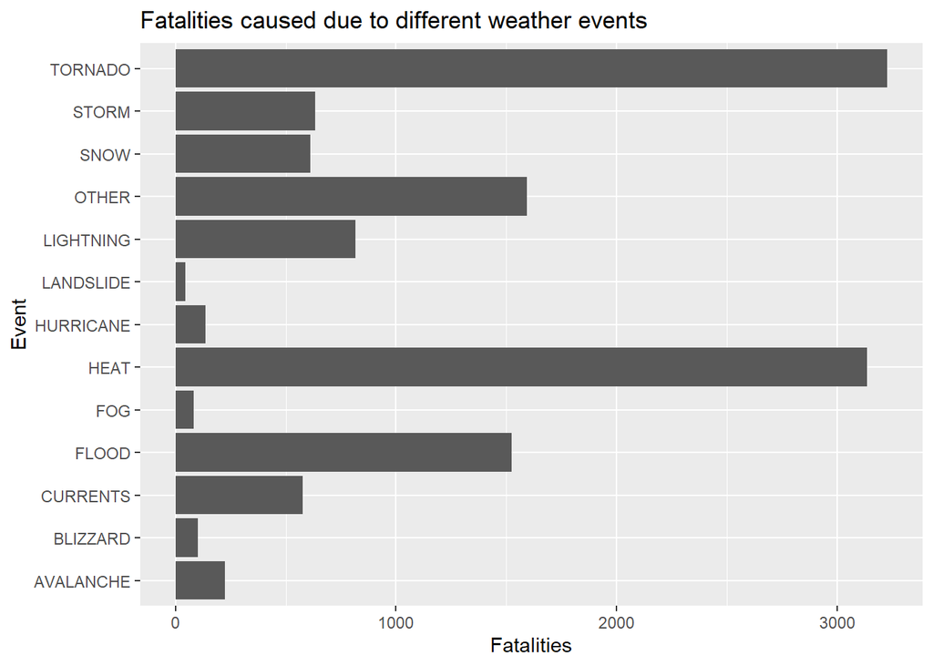

```r
ggplot(fatalities, aes(TYPE, FATALITIES, label=FATALITIES)) + geom_bar(stat="identity") + coord_flip() + xlab("Event") + ylab("Fatalities") + ggtitle("Fatalities caused due to different weather events")
```

We can conclude that Tornadoes and Heat related events are the most fatal weather events across the United States.

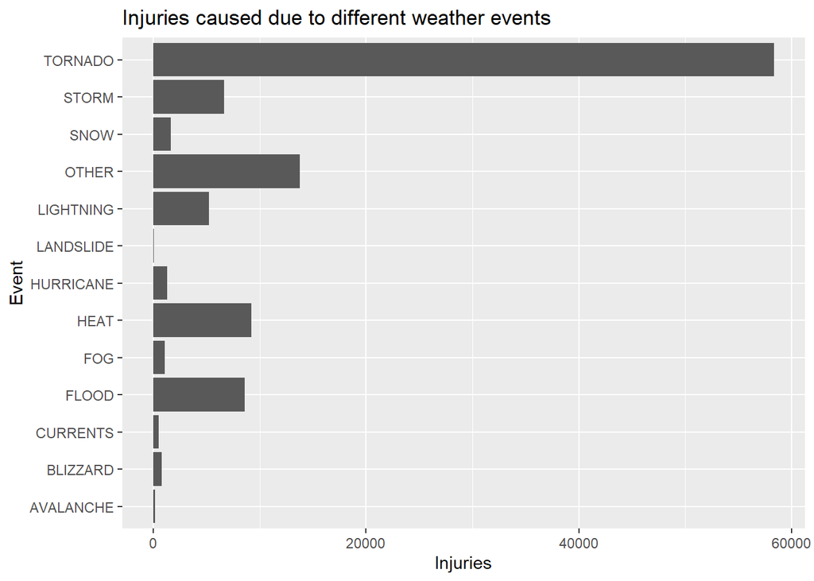

```r
ggplot(injuries, aes(TYPE, INJURIES, label=INJURIES)) + geom_bar(stat="identity") + coord_flip() + xlab("Event") + ylab("Injuries") + ggtitle("Injuries caused due to different weather events")
```

We can conclude from the above plot that tornadoes cause the most injuries as compared to other weather events.

*Across the United States, which types of events have the greatest economic consequences?*

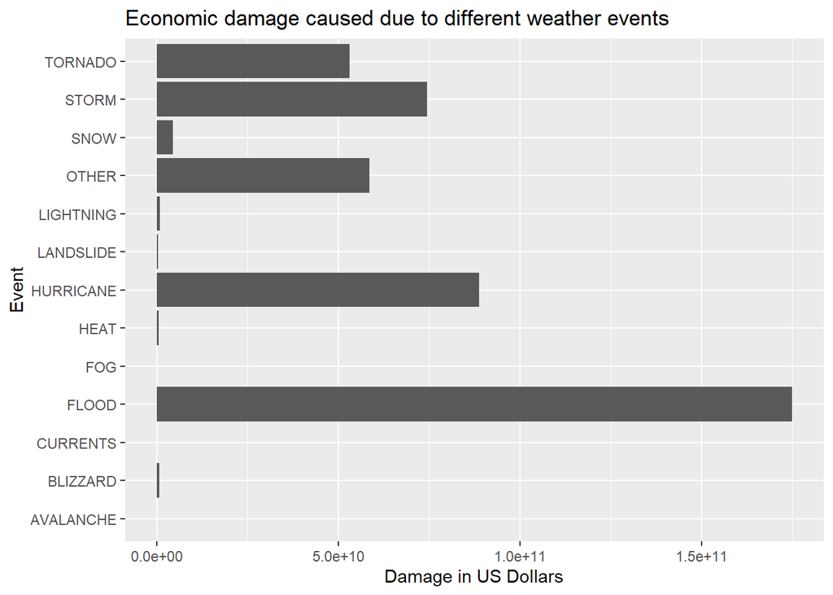

```r
ggplot(TotalDmg, aes(EVENT, DAMAGE, label=DAMAGE)) + geom_bar(stat="identity") + coord_flip() + xlab("Event") + ylab("Damage in US Dollars") + ggtitle("Economic damage caused due to different weather events")
```

We can conclude that flood cause the most Economic damage than other weather events.